# Econometria III Aula 2

Mestrado Profissional em Administração

Prof. Dr. Washington Santos da Silva

19/10/2026

## Programação da aula

### Aula anterior

- Introdução ao modelo de **efeitos fixos**

### Hoje

- Fundamentos: endogeneidade, consistência e viés de variável omitida
- Modelo de efeitos aleatórios: formulação e estimação
- Estimando modelos de efeitos fixos e de efeitos aleatórios com R
- Teste de Hausman

## Richard Feynman

> “Aprendi muito cedo a diferença entre saber o nome de alguma coisa e conhecer essa coisa.”

— Richard Feynman, *What Do You Care What Other People Think?* (1988, tradução livre).

Em Econometria, conhecer o nome de um estimador ou saber executar um comando não é suficiente.

Precisamos compreender **o que ele estima, quais hipóteses sustentam suas propriedades e em quais circunstâncias essas propriedades podem falhar**.

Fundamentos: endogeneidade, consistência e viés de variável omitida

## Introdução

Para entender não apenas modelos econométricos para dados em painel, mas a econometria moderna, alguns conceitos são fundacionais:

- **Exogeneidade/Endogeneidade**
- **Estimadores (não) viesados e (in)consistentes**
- **Viés de variável omitida**

Assim, vamos revisar alguns desses conceitos antes de introduzir os modelos de efeitos aleatórios.

## Hipótese de Exogeneidade

A hipótese de exogeneidade do modelo de regressão linear exige que:

$$\boxed{\mathbb{E}(\varepsilon_i \mid X_i) = 0}$$

onde $X_i$ representa o vetor de variáveis explicativas da observação $i$.

Essa condição significa que, dados os valores das variáveis explicativas, o erro não possui um componente sistematicamente previsível.

Sob as demais condições usuais do modelo linear, essa condição é fundamental para que os estimadores de MQO sejam:

- **não viesados em amostra finita**;
- consistentes quando $n \rightarrow \infty$.

## Hipótese de Exogeneidade

### Implicações

Pela **lei das expectativas iteradas**, a condição de exogeneidade estrita

$$\mathbb{E}(\varepsilon_i \mid X_i) = 0$$

implica que $\mathbb{E}(\varepsilon_i)=0$ e $\operatorname{Cov}(x_{ij},\varepsilon_i)=0$.

Portanto, a condição $\mathbb{E}(\varepsilon_i \mid X_i)=0$ é **mais forte** que simplesmente exigir:

- $\mathbb{E}(\varepsilon_i)=0$;
- $\operatorname{Cov}(x_{ij},\varepsilon_i)=0$ para cada variável explicativa.

Essas condições mais fracas, mesmo consideradas conjuntamente, **não implicam exogeneidade estrita**.

## Violação da Exogeneidade

A hipótese de **exogeneidade estrita** é violada quando a condição

$$\mathbb{E}(\varepsilon_i \mid X_i) = 0$$

não é satisfeita.

Em particular, se para alguma variável explicativa $x_{ij}$ temos $\operatorname{Cov}(x_{ij},\varepsilon_i) \neq 0$, então a hipótese de exogeneidade estrita necessariamente falha.

A recíproca, porém, não é verdadeira:

$\operatorname{Cov}(x_{ij},\varepsilon_i)=0$ para todas as variáveis explicativas **não é suficiente para garantir exogeneidade estrita**.

## Situações que podem violar a exogeneidade

### **Especificação funcional incorreta**

- Se o modelo assume uma forma funcional inadequada — por exemplo, linear quando deveria incluir um termo quadrático —, parte sistemática da relação passa a integrar o termo de erro.
- Nesse caso, podemos ter $\mathbb{E}(\varepsilon_i \mid X_i) \neq 0$, ou seja, endogeneidade.

### **Viés de variável omitida**

- Ocorre quando uma variável relevante ($x_{2}$, por exemplo) é omitida do modelo, isto é, seu $\beta_2 \neq 0$.
- Se essa variável omitida também estiver correlacionada com alguma variável explicativa incluída ($\operatorname{Cov}(x_{1},x_{2}) \neq 0$), sua omissão faz com que essa regressora fique correlacionada com o termo de erro.
- Nesse caso, o estimador de MQO do coeficiente afetado será viesado e inconsistente.

## Situações que podem violar a exogeneidade

### **Erro de mensuração**

- Quando uma variável explicativa é medida com erro, esse erro pode passar a integrar o termo de erro do modelo e tornar a regressora observada correlacionada com ele.
- No caso clássico de erro de mensuração em uma regressora, o estimador de MQO do coeficiente afetado será, em geral, viesado e inconsistente

### **Simultaneidade**

- Ocorre quando $y_i$ e uma ou mais variáveis explicativas são determinados conjuntamente.
- Nesse caso, a variável explicativa é, em geral, correlacionada com o termo de erro, tornando o estimador de MQO do coeficiente afetado viesado e inconsistente.
- Exemplo clássico: preço e quantidade determinados simultaneamente por oferta e demanda.

## Situações que podem violar a exogeneidade

### **Variável dependente defasada e autocorrelação**

Considere um modelo dinâmico:

$$y_t = \beta_0 + \beta_1 y_{t-1} + \beta_2 x_t + e_t.$$

A variável dependente defasada pode ser não correlacionada com $e_t$, mas isso não garante exogeneidade estrita. A autocorrelação pode gerar:

$$\operatorname{Cov}(y_{t-1},e_t) \neq 0.$$

Suponha, por exemplo, que os erros sigam um processo AR(1):

$$e_t = \rho e_{t-1} + v_t,$$

em que $v_t$ é uma inovação não correlacionada com o passado.

Como $y_{t-1}$ contém $e_{t-1}$ e, se $\rho \neq 0$, $e_{t-1}$ também afeta $e_t$, temos, em geral, $\operatorname{Cov}(y_{t-1},e_t) \neq 0$.

Nesse caso, o estimador de MQO de $\beta_1$ será viesado e inconsistente.

## Propriedades dos estimadores

Endogeneidade diz respeito à relação entre as variáveis explicativas e o termo de erro.

Viés e consistência, por sua vez, são propriedades dos estimadores e podem ser afetadas quando a hipótese de exogeneidade falha.

Para analisar essas propriedades, é útil distinguir duas perspectivas:

- Propriedades em amostra finita, para um tamanho de amostra $n$ fixo;
- Propriedades assintóticas, que descrevem o comportamento do estimador quando $n \rightarrow \infty$.

## Propriedades de estimadores em amostras finitas

Para um tamanho de amostra $n$ **fixo**, examinamos a distribuição amostral de um estimador $\hat{\theta}$ e propriedades como:

1. **Valor esperado:** $\mathbb{E}(\hat{\theta})$
2. **Variância:** $\operatorname{Var}(\hat{\theta})$
3. **Erro quadrático médio:** $\operatorname{EQM}(\hat{\theta}) = E\left[ (\hat{\theta} - \theta)^2 \right] = \operatorname{Var}(\hat{\theta}) + [\operatorname{Viés}(\hat{\theta})]^2$

Essas medidas descrevem como o estimador se comportaria em **repetidas amostras de mesmo tamanho $n$** extraídas da população.

## Estimador não viesado

Um estimador $\hat{\theta}$ é não viesado para um parâmetro $\theta$ se seu valor esperado é igual ao valor verdadeiro do parâmetro.

Em termos de amostragem repetida, a distribuição amostral de $\hat{\theta}$ está **centrada** em $\theta$.

Matematicamente:

$$\mathbb{E}(\hat{\theta}) = \theta$$
Assim o viés é dado por:

$$\mathop{\text{Viés}} \left( \hat{\theta} \right) = \mathop{\boldsymbol{E}}\left[ \hat{\theta} \right] - \theta$$

## Viés de um estimador

**Estimador não viesado:** $\mathop{\boldsymbol{E}}\left[ \hat{\beta} \right] = \beta$

[figure not shown]

**Estimador viesado:** $\mathop{\boldsymbol{E}}\left[ \hat{\beta} \right] \neq \beta$

[figure not shown]

## Ausência de viés dos estimadores de MQO com amostra finita

$$\begin{align*}
E\left[ \hat{\beta}_1 | x \right] &= \mathop{\boldsymbol{E}}\left[ \beta_1 + \dfrac{\sum_i\left(x_i - \overline{x}\right)
\varepsilon_i}{\sum_i\left(x_i -\overline{x}\right)^2} \middle| x \right] \\[0.5em]
&= \beta_1 + \mathop{\boldsymbol{E}}\left[ \dfrac{\sum_i\left(x_i - \overline{x}\right) \varepsilon_i}{\sum_i\left(x_i -\overline{x}\right)^2} \middle| x \right] \\[0.5em]
&= \beta_1 + \dfrac{\sum_i\left(x_i - \overline{x}\right)}{\sum_i\left(x_i -\overline{x}\right)^2} \color{#e64173}{\underbrace{\mathop{\boldsymbol{E}}\left[\varepsilon_i \middle| x \right]}_{=0}} \\[0.5em]
E\left[ \hat{\beta}_1 | x \right] &= \beta_1
\end{align*}$$

O mesmo é válido para $\hat \beta_0$.

Assim, os **estimadores de MQO** dos parâmetros $\beta_0$ e $\beta_1$ de um modelo de regressão linear simples são não-viesados em amostra finita, sob a hipótese de exogeneidade.

## Estimador eficiente

Um estimador é eficiente, dentro de uma classe de estimadores não viesados para um parâmetro $\theta$, se possui a **menor variância** entre os estimadores dessa classe.

A variância da distribuição amostral de $\hat{\theta}$ é:

$$\operatorname{Var}(\hat{\theta})
=
\mathbb{E}\left[
\left(\hat{\theta}-\mathbb{E}(\hat{\theta})\right)^2
\right].$$

Assim, entre dois estimadores não viesados $\hat{\theta}_1$ e $\hat{\theta}_2$ do mesmo parâmetro,

$$\operatorname{Var}(\hat{\theta}_1)
<
\operatorname{Var}(\hat{\theta}_2)$$

implica que $\hat{\theta}_1$ é **mais eficiente** que $\hat{\theta}_2$.

## Eficiência de um estimador

[figure not shown]

Qual dos dois estimadores é mais eficiente?

## Consistência

### Comportamento assintótico dos estimadores

As propriedades em amostra finita descrevem o comportamento de um estimador para um tamanho de amostra $n$ fixo.

Nova pergunta

Como um estimador se comporta à medida que o tamanho da amostra aumenta ($n \rightarrow \infty$)?

Essa pergunta nos leva às propriedades assintóticas, que descrevem o comportamento dos estimadores em **grandes amostras**.

Uma dessas propriedades é a consistência:

à medida que $n$ aumenta, a distribuição amostral de um estimador consistente se concentra cada vez mais em torno do verdadeiro valor do parâmetro.

## Consistência

### Limite de probabilidade

Em amostras finitas, características como $\mathbb{E}(\hat{\theta})$ e $\operatorname{Var}(\hat{\theta})$ nos ajudam a descrever a **distribuição amostral** de um estimador para um $n$ fixo.

Para estudar seu **comportamento assintótico**, uma ferramenta fundamental é o limite de probabilidade.

O limite de probabilidade indica para qual valor o estimador **converge em probabilidade** à medida que

$$n \rightarrow \infty.$$

Assim, em vez de perguntar apenas onde a distribuição de $\hat{\theta}$ está centrada para um dado $n$, perguntamos o que acontece com $\hat{\theta}$ quando o tamanho da amostra cresce indefinidamente.

## Consistência

### Limite de probabilidade

Seja $\hat{\theta}_n$ um estimador de $\theta$ calculado com uma amostra de tamanho $n$.

Dizemos que $\hat{\theta}_n$ **converge em probabilidade** para $\theta$ se, para qualquer $\varepsilon > 0$, temos:

$$\lim_{n\rightarrow\infty}
P\left(\left|\hat{\theta}_n-\theta\right|>\varepsilon\right)=0.$$

Isso significa que, à medida que $n\rightarrow\infty$, a probabilidade de $\hat{\theta}_n$ diferir de $\theta$ por mais do que um valor extremamente pequeno $\varepsilon$ tende a zero.

**Intuitivamente:** a distribuição de $\hat{\theta}_n$ se concentra cada vez mais em torno de $\theta$ à medida que o tamanho da amostra aumenta.

## Consistência

### Limites de probabilidade

As seguintes formas expressam a mesma ideia:

- O **limite de probabilidade** de $\hat{\theta}_n$ é $\theta$;
- $\operatorname{plim}\hat{\theta}_n = \theta$;
- $\hat{\theta}_n \xrightarrow{p} \theta$: $\hat{\theta}_n$ **converge em probabilidade** para $\theta$.

## Consistência

### Propriedades dos limites de probabilidade

Se $X_n \xrightarrow{p} a$ e $Y_n \xrightarrow{p} b$, sendo $a$ e $b$ constantes, então:

- $\operatorname{plim}(X_n + Y_n) = a + b$
- $\operatorname{plim}(X_n Y_n) = ab$
- para uma constante $c$, $\operatorname{plim}(c) = c$
- se $b \neq 0$, $\displaystyle \operatorname{plim}\left(\frac{X_n}{Y_n}\right)=\frac{a}{b}$
- se $f(\cdot)$ é contínua em $a$, $\operatorname{plim}\big(f(X_n)\big)=f(a)$

## Consistência

### Estimadores consistentes

Dizemos que $\hat{\theta}_n$ é um **estimador consistente** de $\theta$ se

$$\operatorname{plim}\hat{\theta}_n = \theta,$$

ou, equivalentemente,

$$\hat{\theta}_n \xrightarrow{p} \theta.$$

**Intuitivamente:** à medida que o tamanho da amostra aumenta, a distribuição amostral de $\hat{\theta}_n$ se concentra cada vez mais em torno do verdadeiro valor $\theta$.

Se $\hat{\theta}_n$ **não converge em probabilidade para $\theta$**, o estimador é inconsistente para esse parâmetro.

## Consistência

### Três estimadores de $\mu_x$

Considere uma amostra aleatória $X_1,\ldots,X_n$ de uma população normal com

$$X_i \sim N(\mu_x,\sigma^2).$$

Queremos estimar a média populacional $\mu_x$ usando três estimadores concorrentes:

1. A primeira observação: $X_1$
2. A média amostral: $\displaystyle \overline{X}=\frac{1}{n}\sum_{i=1}^n X_i$
3. Um estimador alternativo: $\displaystyle \widetilde{X}=\frac{1}{n+1}\sum_{i=1}^n X_i$

Vamos comparar suas propriedades **em amostras finitas** e quando $n\rightarrow\infty$.

## Consistência

### Viés em amostra finita

Para os três estimadores de $\mu_x$:

1. $\mathbb{E}(X_1)=\mu_x.$
2. $\mathbb{E}(\overline{X}) = \mathbb{E}\left(\frac{1}{n}\sum_{i=1}^n X_i\right) = \frac{1}{n}\sum_{i=1}^n\mathbb{E}(X_i) = \mu_x$
3. $\mathbb{E}(\widetilde{X}) = \mathbb{E}\left(\frac{1}{n+1}\sum_{i=1}^n X_i\right) = \frac{n}{n+1}\mu_x$.

Logo, $\operatorname{Viés}(\widetilde{X}) = -\frac{\mu_x}{n+1}.$

Assim, $X_1$ e $\overline{X}$ são não viesados, enquanto $\widetilde{X}$ é viesado em amostra finita sempre que $\mu_x \neq 0$.

A seguir, veremos o que acontece com esses estimadores quando $n\rightarrow\infty$.

## Consistência

Distribuições amostrais de $\color{#FFA500}{X_1}$, $\color{#e64173}{\overline{X}}$ e $\color{#314f4f}{\widetilde{X}}$  
$n = 2$

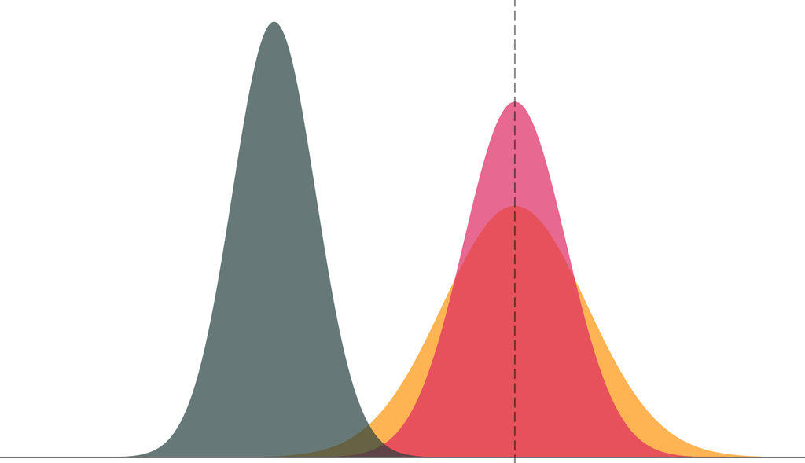

## Consistência

Distribuições amostrais de $\color{#FFA500}{X_1}$, $\color{#e64173}{\overline{X}}$ e $\color{#314f4f}{\widetilde{X}}$  
$n = 5$

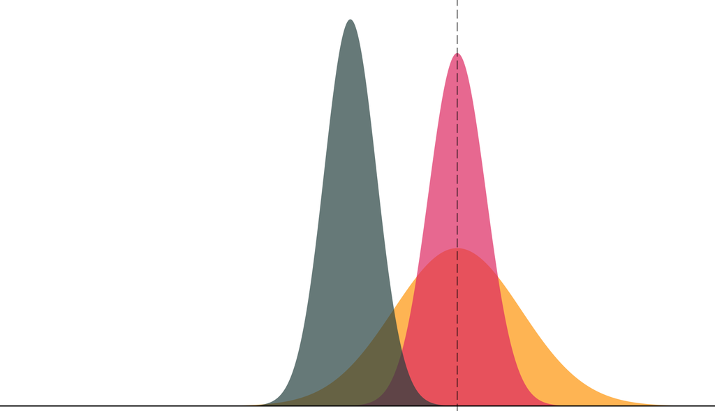

## Consistência

Distribuições amostrais de $\color{#FFA500}{X_1}$, $\color{#e64173}{\overline{X}}$ e $\color{#314f4f}{\widetilde{X}}$  
$n = 10$

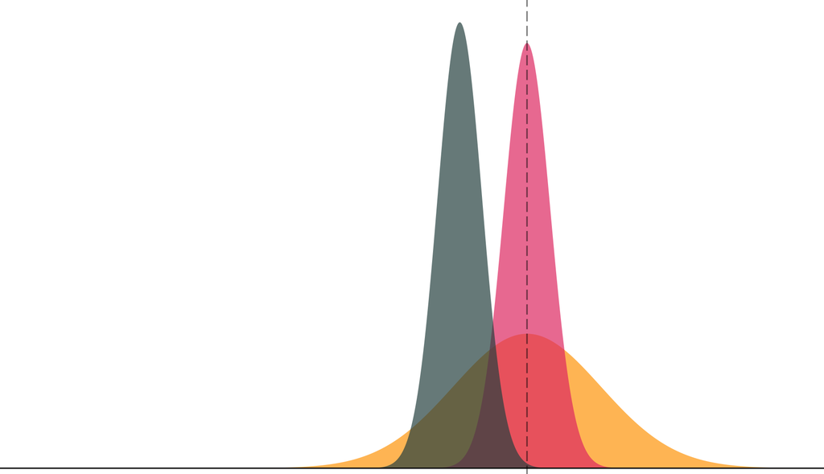

## Consistência

Distribuições amostrais de $\color{#FFA500}{X_1}$, $\color{#e64173}{\overline{X}}$ e $\color{#314f4f}{\widetilde{X}}$  
$n = 30$

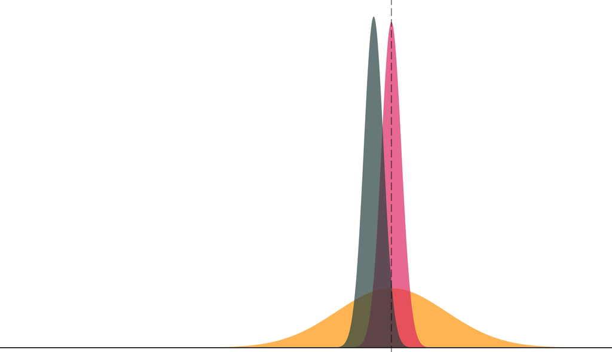

## Consistência

Distribuições amostrais de $\color{#FFA500}{X_1}$, $\color{#e64173}{\overline{X}}$ e $\color{#314f4f}{\widetilde{X}}$  
$n = 50$

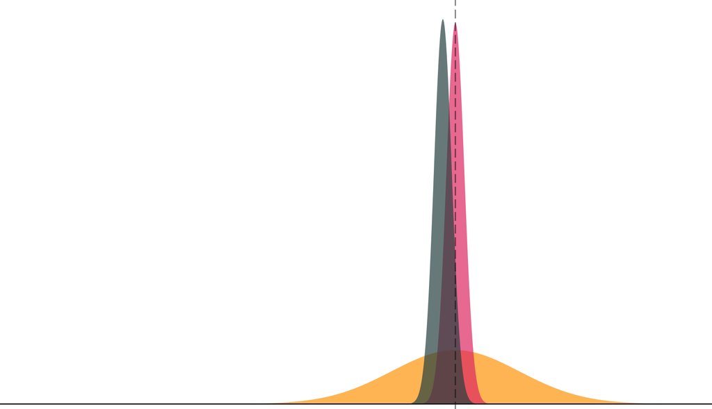

## Consistência

Distribuições de $\color{#FFA500}{X_1}$, $\color{#e64173}{\overline{X}}$ e $\color{#314f4f}{\widetilde{X}}$  
$n = 100$

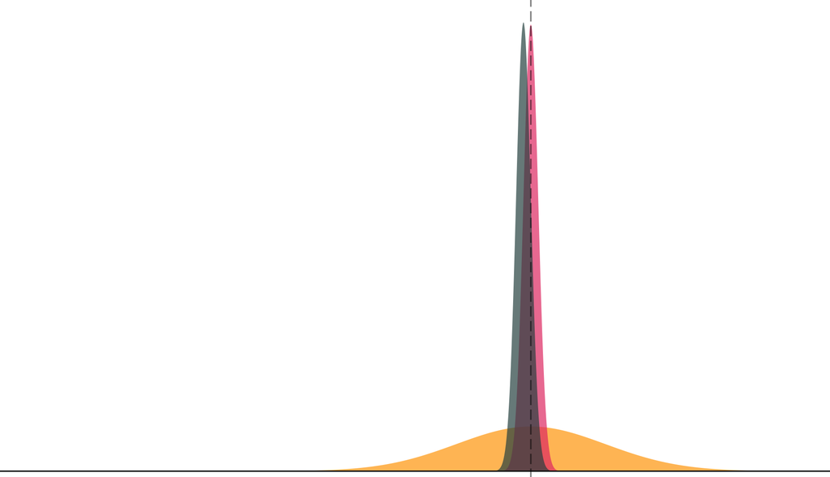

## Consistência

Distribuições de $\color{#FFA500}{X_1}$, $\color{#e64173}{\overline{X}}$ e $\color{#314f4f}{\widetilde{X}}$  
$n = 500$

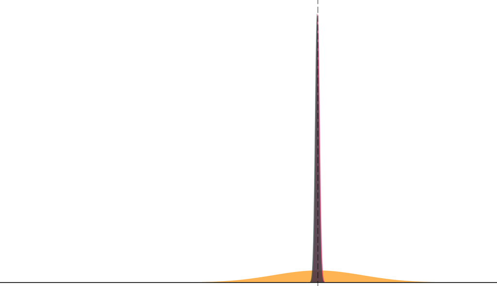

## Consistência

Distribuições de $\color{#FFA500}{X_1}$, $\color{#e64173}{\overline{X}}$ e $\color{#314f4f}{\widetilde{X}}$  
$n = 1000$

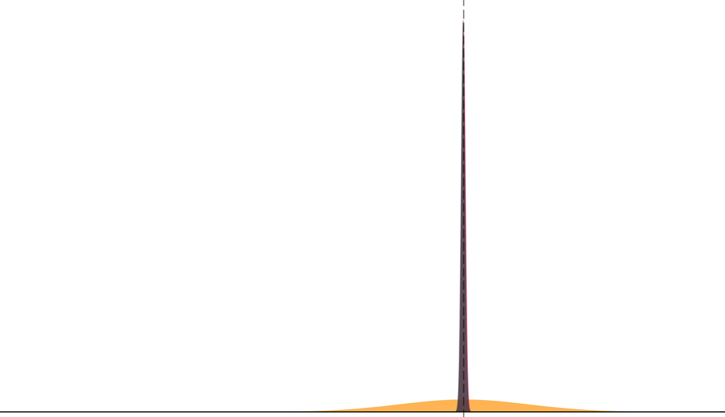

## Consistência

### Qual é a conclusão?

- Um estimador pode ser não viesado, mas inconsistente, por exemplo, $\color{#FFA500}{X_1}$.
- Um estimador pode ser não viesado e consistente, por exemplo, $\color{#e64173}{\overline{X}}$.
- Um estimador pode ser viesado em amostra finita, mas consistente, por exemplo, $\color{#314f4f}{\widetilde{X}}$.
- Um estimador pode ser viesado e inconsistente, por exemplo, $\overline{X} - 50$.

Ausência de viés e consistência são propriedades **diferentes** de um estimador.

Nos modelos de regressão, essa distinção é especialmente importante porque a endogeneidade, em geral, torna os estimadores de MQO dos coeficientes afetado viesado e inconsistente.

## Consistência

### Por que a consistência importa?

1. Nem sempre é possível obter um estimador **não viesado em amostra finita**. Ainda assim, desejamos que ele seja consistente.
2. Em econometria, muitas propriedades exatas em amostras finitas são difíceis de obter. Por isso, grande parte da análise dos estimadores se apoia em suas **propriedades assintóticas**.
3. Nos modelos de regressão, sob exogeneidade e as demais condições usuais, o MQO é consistente. Quando há endogeneidade, essa consistência pode falhar.

Atenção: um estimador consistente pode ser **viesado em amostra finita**.

## Consistência dos estimadores de MQO

Sob exogeneidade e as demais condições usuais, os estimadores de MQO apresentam duas propriedades assintóticas centrais:

1. Consistência
2. **Normalidade assintótica**

Vamos examinar a primeira propriedade no caso da regressão linear simples:

$$y_i = \beta_0 + \beta_1 x_i + \varepsilon_i.$$

A questão é: **sob quais condições** o estimador $\hat{\beta}_1$ de MQO é consistente? Ou seja:

$$\operatorname{plim}\hat{\beta}_1=\beta_1?$$

## Consistência dos estimadores de MQO

### Demonstração da consistência

Primeiro, recordemos a expressão do estimador de $\beta_1$:

$$\hat{\beta}_1
=
\beta_1
+
\dfrac{
\sum_i (x_i-\overline{x})\varepsilon_i
}{
\sum_i (x_i-\overline{x})^2
}.$$

Para estudar seu comportamento quando $n\rightarrow\infty$, é conveniente expressar as duas somas como **médias amostrais**. Dividindo cada soma por $n$:

$$\hat{\beta}_1
=
\beta_1
+
\dfrac{
\frac{1}{n}\sum_i (x_i-\overline{x})\varepsilon_i
}{
\frac{1}{n}\sum_i (x_i-\overline{x})^2
}.$$

## Consistência dos estimadores de MQO

### Demonstração da consistência

Queremos determinar o limite de probabilidade de $\hat{\beta}_1$:

$$\operatorname{plim}\hat{\beta}_1
=
\operatorname{plim}
\left[
\beta_1
+
\dfrac{
\frac{1}{n}\sum_i (x_i-\overline{x})\varepsilon_i
}{
\frac{1}{n}\sum_i (x_i-\overline{x})^2
}
\right].$$

Pelas propriedades dos limites de probabilidade,

$$\operatorname{plim}\hat{\beta}_1
=
\beta_1
+
\dfrac{
\operatorname{plim}\left[
\frac{1}{n}\sum_i (x_i-\overline{x})\varepsilon_i
\right]
}{
\operatorname{plim}\left[
\frac{1}{n}\sum_i (x_i-\overline{x})^2
\right]
}.$$

Sob amostragem aleatória e condições usuais de momentos, esses momentos amostrais convergem para seus correspondentes populacionais:

$$\boxed{
\operatorname{plim}\hat{\beta}_1
=
\beta_1
+
\dfrac{\operatorname{Cov}(x,\varepsilon)}
{\operatorname{Var}(x)}
}$$

## Consistência dos estimadores de MQO

### Demonstração da consistência

Do slide anterior,

$$\operatorname{plim}\hat{\beta}_1
=
\beta_1
+
\dfrac{\operatorname{Cov}(x,\varepsilon)}
{\operatorname{Var}(x)}.$$

Pela hipótese de exogeneidade: $\mathbb{E}(\varepsilon_i\mid x_i)=0,$, o que implica $\operatorname{Cov}(x,\varepsilon)=0$.

Assim, desde que $\operatorname{Var}(x)>0$,

$$\boxed{
\operatorname{plim}\hat{\beta}_1
=
\beta_1
+
\dfrac{0}{\operatorname{Var}(x)}
=
\beta_1
}$$

Portanto, **sob exogeneidade** e as demais condições utilizadas na demonstração, $\hat{\beta}_1$ é um estimador consistente de $\beta_1$.

Se, ao contrário, $\operatorname{Cov}(x,\varepsilon)\neq 0$, o termo adicional permanece no limite de probabilidade e, em geral, o estimador de MQO é inconsistente.

## Viés de variável omitida

### Por que retomar esse problema?

Nos slides anteriores, vimos que, quando uma regressora está correlacionada com o termo de erro, o estimador de MQO pode ser **viesado e inconsistente**.

Uma fonte clássica dessa correlação é a **omissão de uma variável relevante**:

Se a variável omitida afeta $y$ e estiver correlacionada com uma regressora incluída, seu efeito passa a integrar o termo de erro, gerando endogeneidade.

Na aula sobre **efeitos fixos**, já vimos que as unidades podem apresentar **heterogeneidade individual não observada, invariável no tempo**.

*Exemplos:* habilidade não observada de um trabalhador, **qualidade gerencial** não observada de uma empresa ou outras características específicas da unidade que permaneçam estáveis durante o período observado.

Se essa heterogeneidade estiver correlacionada com os regressores e for ignorada, ela funciona como uma variável omitida e pode tornar os estimadores de MQO **viesados e inconsistentes**.

Retomar o viés de variável omitida nos ajudará a compreender melhor por que essa correlação é central na distinção entre **efeitos fixos** e **efeitos aleatórios**.

## Viés de variável omitida

### Quando surge o viés?

Suponha que o modelo verdadeiro seja

$$y_i = \beta_0 + \beta_1 x_{1i} + \beta_2 x_{2i} + \varepsilon_i,$$

e que esteja corretamente especificado e satisfaça a hipótese de exogeneidade.

Se omitirmos $x_2$, haverá **viés de variável omitida** quando duas condições forem satisfeitas:

1. $x_2$ é **relevante no modelo verdadeiro**: $\beta_2 \neq 0$
2. $x_2$ é **correlacionada com a regressora incluída** $x_1$: $\operatorname{Cov}(x_1,x_2)\neq 0.$

## Viés de variável omitida

### O viés desaparece em grandes amostras?

Suponha novamente que o modelo verdadeiro seja

$$y_i = \beta_0 + \beta_1 x_{1i} + \beta_2 x_{2i} + \varepsilon_i.$$

Se omitirmos $x_2$, especificamos

$$y_i = \beta_0 + \beta_1 x_{1i} + \widetilde{\varepsilon}_i,$$

onde $\widetilde{\varepsilon}_i = \beta_2 x_{2i} + \varepsilon_i$.

Portanto, o efeito de $x_2$ passa a integrar o **termo de erro do modelo especificado**.

Quando as duas condições anteriores são satisfeitas, surge **viés de variável omitida**.

**Pergunta:** aumentar $n$ elimina esse viés?

Para verificar se a omissão continua afetando o estimador **assintoticamente**, analisamos sua consistência:

$$\operatorname{plim}\hat{\beta}_1 \overset{?}{=} \beta_1.$$

## Viés de variável omitida

### A inconsistência do estimador de MQO

Do slide anterior,

$$y_i = \beta_0 + \beta_1 x_{1i} + \widetilde{\varepsilon}_i,$$

onde $\widetilde{\varepsilon}_i = \beta_2 x_{2i} + \varepsilon_i$.

Já demonstramos que, para uma regressão linear simples,

$$\operatorname{plim}\hat{\beta}_1
=
\beta_1
+
\dfrac{
\operatorname{Cov}(x_1,\widetilde{\varepsilon})
}{
\operatorname{Var}(x_1)
}.$$

Substituindo $\widetilde{\varepsilon} = \beta_2 x_2 + \varepsilon$,

$$\operatorname{plim}\hat{\beta}_1
=
\beta_1
+
\dfrac{
\operatorname{Cov}(x_1,\beta_2 x_2+\varepsilon)
}{
\operatorname{Var}(x_1)
}.$$

## Viés de variável omitida

### Decompondo a covariância

Do slide anterior,

$$\operatorname{plim}\hat{\beta}_1
=
\beta_1
+
\dfrac{
\operatorname{Cov}(x_1,\beta_2x_2+\varepsilon)
}{
\operatorname{Var}(x_1)
}.$$

Pela linearidade da covariância,

$\operatorname{Cov}(x_1,\beta_2x_2+\varepsilon) = \beta_2\operatorname{Cov}(x_1,x_2) + \operatorname{Cov}(x_1,\varepsilon)$.

Assim,

$$\operatorname{plim}\hat{\beta}_1
=
\beta_1
+
\dfrac{
\beta_2\operatorname{Cov}(x_1,x_2)
+
\operatorname{Cov}(x_1,\varepsilon)
}{
\operatorname{Var}(x_1)
}.$$

## Viés de variável omitida

### Aplicando a exogeneidade

Do slide anterior,

$$\operatorname{plim}\hat{\beta}_1
=
\beta_1
+
\dfrac{
\beta_2\operatorname{Cov}(x_1,x_2)
+
\operatorname{Cov}(x_1,\varepsilon)
}{
\operatorname{Var}(x_1)
}.$$

Como o modelo verdadeiro satisfaz a hipótese de exogeneidade, $\mathbb{E}(\varepsilon_i \mid x_{1i},x_{2i})=0$ e, portanto, $\operatorname{Cov}(x_1,\varepsilon)=0$.

Assim,

$$\boxed{
\operatorname{plim}\hat{\beta}_1
=
\beta_1
+
\beta_2
\dfrac{\operatorname{Cov}(x_1,x_2)}
{\operatorname{Var}(x_1)}
}$$

## Viés de variável omitida

### Quando a omissão gera inconsistência?

Obtivemos:

$$\operatorname{plim}\hat{\beta}_1
=
\beta_1
+
\beta_2
\dfrac{\operatorname{Cov}(x_1,x_2)}
{\operatorname{Var}(x_1)}.$$

A omissão de $x_2$ torna $\hat{\beta}_1$ inconsistente quando duas condições são satisfeitas:

1. $x_2$ é **relevante no modelo verdadeiro**: $\beta_2 \neq 0$;
2. $x_2$ é **correlacionada com a regressora incluída** $x_1$: $\operatorname{Cov}(x_1,x_2)\neq 0$.

Se ambas forem satisfeitas, $\operatorname{plim}\hat{\beta}_1 \neq \beta_1$, mesmo quando $n\rightarrow\infty$.

Portanto, **aumentar o tamanho da amostra não elimina o viés decorrente da omissão**: o estimador de MQO de $\beta_1$ permanece inconsistente.

## Viés de variável omitida

### Exemplo: salário, escolaridade e gênero

Considere o modelo populacional

$$\text{Salário}_i
=
\beta_0
+
\beta_1\text{Escolaridade}_i
+
\beta_2\text{Homem}_i
+
\varepsilon_i,$$

em que $\text{Homem}_i=1$ para homens e $0$ para mulheres.

- $\beta_1$: diferença esperada no salário associada a um ano adicional de escolaridade, **mantendo o gênero constante**;
- $\beta_2$: diferença esperada no salário entre homens e mulheres com a **mesma escolaridade**.

Interpretar $\beta_1$ como **retorno causal da escolaridade** ou $\beta_2$ como **discriminação** exige hipóteses adicionais de identificação.

## Viés de variável omitida

### Omitindo gênero

Partindo do modelo populacional

$$\text{Salário}_i
=
\beta_0
+
\beta_1\text{Escolaridade}_i
+
\beta_2\text{Homem}_i
+
\varepsilon_i,$$

suponha que estimemos um modelo que omite gênero:

$$\text{Salário}_i
=
\beta_0
+
\beta_1\text{Escolaridade}_i
+
\widetilde{\varepsilon}_i,$$

onde $\widetilde{\varepsilon}_i = \beta_2\text{Homem}_i+\varepsilon_i$.

Assim, o efeito da variável omitida passa a integrar o **termo de erro**.

O próximo passo é verificar se $\text{Escolaridade}_i$ fica correlacionada com $\widetilde{\varepsilon}_i$.

## Viés de variável omitida

### Quando a omissão de gênero gera viés?

Pela exogeneidade do modelo populacional, $\operatorname{Cov}(\text{Escolaridade}_i,\varepsilon_i)=0$.

Como $\widetilde{\varepsilon}_i = \beta_2\text{Homem}_i+\varepsilon_i$,

$$\operatorname{Cov}(\text{Escolaridade}_i,\widetilde{\varepsilon}_i)
=
\beta_2
\operatorname{Cov}(\text{Escolaridade}_i,\text{Homem}_i).$$

Portanto, se $\beta_2\neq0$ **e** $\operatorname{Cov}(\text{Escolaridade}_i,\text{Homem}_i)\neq0$, a escolaridade fica correlacionada com o termo de erro do modelo especificado:

**surge endogeneidade, e o estimador de MQO de $\beta_1$ será viesado e inconsistente.**

Se escolaridade e gênero não estiverem correlacionados, a omissão de gênero não desloca a inclinação populacional associada à escolaridade, embora possa aumentar a variância do erro e reduzir a precisão da estimação.

## Viés de variável omitida

### Visualizando o viés

Vamos visualizar esse resultado com dados simulados.

O modelo populacional utilizado na simulação é

$$\text{Salário}_i
=
20
+
0.5\times\text{Escolaridade}_i
+
10\times\text{Homem}_i
+
\varepsilon_i.$$

Na simulação, homens têm, em média, **menos anos de escolaridade** que mulheres. Assim, $\operatorname{Cov}(\text{Escolaridade},\text{Homem})<0$.

Como $\beta_2=10>0$, esperamos que a omissão de gênero produza uma **inclinação estimada para escolaridade menor que a verdadeira**.

## Viés de variável omitida

Modelo populacional: $\text{Salário}_i = 20 + 0.5 \times \text{Escolaridade}_i + 10 \times \text{Homem}_i + \varepsilon_i$

Primeiro, observemos a relação entre salário e escolaridade **sem distinguir o gênero**.

[figure not shown]

## Viés de variável omitida: Exemplo

$\text{Salário}_i = 20 + 0.5 \times \text{Escolaridade}_i + 10 \times \text{Homem}_i + \varepsilon_i$

Regressão que omite gênero: $\widehat{\text{Salário}}_i = 31.3 + -0.9 \times \text{Escolaridade}_i$

[figure not shown]

## Viés de variável omitida: **Exemplo, continuação**

$\text{Salário}_i = 20 + 0.5 \times \text{Escolaridade}_i + 10 \times \text{Homem}_i + \varepsilon_i$

Retomando a variável omitida: gênero (**mulher** e **homem**)

[figure not shown]

## Viés de variável omitida: **Exemplo, continuação**

$\text{Salário}_i = 20 + 0.5 \times \text{Escolaridade}_i + 10 \times \text{Homem}_i + \varepsilon_i$

Controlando por gênero: retas ajustadas para **mulheres** e **homens**

[figure not shown]

## Viés de variável omitida

### Uso prático da direção da inconsistência

Na prática, podemos suspeitar da omissão de uma variável relevante que é **não observada**, difícil de medir ou indisponível nos dados.

Mesmo sem observar $x_2$, teoria, evidência prévia e conhecimento do problema podem fornecer argumentos plausíveis sobre:

- o sinal de $\beta_2$;
- o sinal de $\operatorname{Cov}(x_1,x_2)$.

Se ambos forem defensáveis, podemos inferir se $\hat{\beta}_1$ tende, assintoticamente, a ficar **acima ou abaixo** de $\beta_1$.

Essa análise fornece um **diagnóstico qualitativo**:

- ajuda a interpretar em que direção uma omissão pode afetar a estimativa;
- permite avaliar se a omissão tende a aumentar ou reduzir o coeficiente estimado.

## Viés de variável omitida

### Direção da inconsistência

Obtivemos:

$$\operatorname{plim}\hat{\beta}_1
=
\beta_1
+
\beta_2
\dfrac{\operatorname{Cov}(x_1,x_2)}
{\operatorname{Var}(x_1)}.$$

Logo, o **viés assintótico** é

$$\operatorname{plim}\hat{\beta}_1-\beta_1
=
\beta_2
\dfrac{\operatorname{Cov}(x_1,x_2)}
{\operatorname{Var}(x_1)}.$$

Como $\operatorname{Var}(x_1)>0$, a **direção da inconsistência** depende apenas dos sinais de $\beta_2$ e $\operatorname{Cov}(x_1,x_2)$.

## Viés de variável omitida

### Direção da inconsistência

Suponha que $\color{#e64173}{\beta_2>0}$ e $\color{#FFA500}{\operatorname{Cov}(x_1,x_2)>0}$.

Como $\color{#20B2AA}{\operatorname{Var}(x_1)>0}$,

$$\operatorname{plim}\hat{\beta}_1-\beta_1
=
\color{#e64173}{(+)}
\dfrac{\color{#FFA500}{(+)}}{\color{#20B2AA}{(+)}}
>0,$$

portanto $\operatorname{plim}\hat{\beta}_1>\beta_1$.

Nesse caso, o **viés assintótico é positivo**: $\hat{\beta}_1$ converge em probabilidade para um valor acima de $\beta_1$.

$$\begin{matrix}
\enspace & \color{#FFA500}{\operatorname{Cov}(x_1,x_2)>0}
& \color{#FFA500}{\operatorname{Cov}(x_1,x_2)<0} \\
\color{#e64173}{\beta_2>0} & \text{Viés assintótico positivo} & \\
\color{#e64173}{\beta_2<0} & &
\end{matrix}$$

## Viés de variável omitida

### Direção da inconsistência

Suponha que $\color{#e64173}{\beta_2<0}$ e $\color{#FFA500}{\operatorname{Cov}(x_1,x_2)>0}$.

Como $\color{#20B2AA}{\operatorname{Var}(x_1)>0}$,

$$\operatorname{plim}\hat{\beta}_1-\beta_1
=
\color{#e64173}{(-)}
\dfrac{\color{#FFA500}{(+)}}{\color{#20B2AA}{(+)}}
<0,$$

portanto $\operatorname{plim}\hat{\beta}_1<\beta_1$.

Nesse caso, o **viés assintótico é negativo**: $\hat{\beta}_1$ converge em probabilidade para um valor abaixo de $\beta_1$.

$$\begin{matrix}
\enspace & \color{#FFA500}{\operatorname{Cov}(x_1,x_2)>0}
& \color{#FFA500}{\operatorname{Cov}(x_1,x_2)<0} \\
\color{#e64173}{\beta_2>0} & \text{Viés assintótico positivo} & \\
\color{#e64173}{\beta_2<0} & \text{Viés assintótico negativo} &
\end{matrix}$$

## Viés de variável omitida

### Direção da inconsistência

Suponha que $\color{#e64173}{\beta_2>0}$ e $\color{#FFA500}{\operatorname{Cov}(x_1,x_2)<0}$.

Como $\color{#20B2AA}{\operatorname{Var}(x_1)>0}$,

$$\operatorname{plim}\hat{\beta}_1-\beta_1
=
\color{#e64173}{(+)}
\dfrac{\color{#FFA500}{(-)}}{\color{#20B2AA}{(+)}}
<0,$$

portanto $\operatorname{plim}\hat{\beta}_1<\beta_1$.

Nesse caso, o **viés assintótico é negativo**: $\hat{\beta}_1$ converge em probabilidade para um valor abaixo de $\beta_1$.

$$\begin{matrix}
\enspace & \color{#FFA500}{\operatorname{Cov}(x_1,x_2)>0}
& \color{#FFA500}{\operatorname{Cov}(x_1,x_2)<0} \\
\color{#e64173}{\beta_2>0} & \text{Viés assintótico positivo}
& \text{Viés assintótico negativo} \\
\color{#e64173}{\beta_2<0} & \text{Viés assintótico negativo} &
\end{matrix}$$

## Viés de variável omitida

### Direção da inconsistência

Suponha que $\color{#e64173}{\beta_2<0}$ e $\color{#FFA500}{\operatorname{Cov}(x_1,x_2)<0}$.

Como $\color{#20B2AA}{\operatorname{Var}(x_1)>0}$,

$$\operatorname{plim}\hat{\beta}_1-\beta_1
=
\color{#e64173}{(-)}
\dfrac{\color{#FFA500}{(-)}}{\color{#20B2AA}{(+)}}
>0,$$

portanto $\operatorname{plim}\hat{\beta}_1>\beta_1$.

Nesse caso, o **viés assintótico é positivo**: $\hat{\beta}_1$ converge em probabilidade para um valor acima de $\beta_1$.

$$\begin{matrix}
\enspace & \color{#FFA500}{\operatorname{Cov}(x_1,x_2)>0}
& \color{#FFA500}{\operatorname{Cov}(x_1,x_2)<0} \\
\color{#e64173}{\beta_2>0} & \text{Viés assintótico positivo}
& \text{Viés assintótico negativo} \\
\color{#e64173}{\beta_2<0} & \text{Viés assintótico negativo}
& \text{Viés assintótico positivo}
\end{matrix}$$

Modelo de efeitos aleatórios: formulação e estimação

## Modelo geral de regressão para dados em painel

Unidades $i=1,\ldots,N$, observadas nos períodos $t=1,\ldots,T$:

$$y_{it}=\beta_0+x_{it}'\beta+w_i'\gamma+u_i+e_{it}.$$

- $y_{it}$: **variável dependente** da unidade $i$ no período $t$.
- $x_{it}$: **regressoras observadas** que podem variar entre unidades e períodos.
- $w_i$: **regressoras observadas invariáveis no tempo**.
- $u_i$: **heterogeneidade individual não observada**, invariável no tempo.
- $e_{it}$: **erro idiossincrático**, que varia entre unidades e períodos.

O **erro composto** é $v_{it}=u_i+e_{it}$. **EF e EA diferem nas hipóteses sobre $u_i$ e em como o tratam na estimação.**

## Modelo de efeitos fixos

- **Associação permitida:** $u_i$ pode estar sistematicamente associado às regressoras. Não exigimos $E(u_i\mid X_i,w_i)=0$, sendo $X_i$ o conjunto das regressoras da unidade $i$ em todos os períodos.
- **Problema para o MQO agrupado:** se $u_i$ estiver correlacionado com as regressoras, sua presença no erro composto pode gerar **viés de variável omitida e inconsistência**.
- **Estratégia de EF:** a transformação *within* **elimina $u_i$** e utiliza a variação **dentro das unidades ao longo do tempo** para estimar $\beta$.
- **Consequência:** a transformação também elimina $w_i$. Assim, seus coeficientes $\gamma$ **não são identificados pelo estimador *within***.

**Permitir associação entre $u_i$ e as regressoras não dispensa a exogeneidade estrita de $e_{it}$.**

## Efeitos fixos: transformação *within*

Partimos do modelo

$$y_{it}=\beta_0+x_{it}'\beta+w_i'\gamma+u_i+e_{it}.$$

Tomando a média ao longo do tempo para cada unidade $i$:

$$\bar y_i
=
\beta_0+\bar x_i'\beta+w_i'\gamma+u_i+\bar e_i,$$

em que as barras representam **médias temporais da unidade $i$**.

Subtraindo a média individual da equação original:

$$y_{it}-\bar y_i
=
(x_{it}-\bar x_i)'\beta
+
(e_{it}-\bar e_i).$$

Os termos invariáveis no tempo $\beta_0$, $w_i$ e $u_i$ são **eliminados pela transformação**.

## Efeitos fixos: transformação *within*

Definindo

$$\tilde y_{it}=y_{it}-\bar y_i,
\qquad
\tilde x_{it}=x_{it}-\bar x_i,
\qquad
\tilde e_{it}=e_{it}-\bar e_i,$$

obtemos

$$\tilde y_{it}=\tilde x_{it}'\beta+\tilde e_{it}.$$

Aplicar MQO ao modelo transformado produz o **estimador *within*** de efeitos fixos, que usa a variação das regressoras **dentro das unidades ao longo do tempo**.

## Efeitos fixos: hipóteses

1. **Exogeneidade estrita:** $E(e_{it}\mid X_i,u_i)=0$. O erro idiossincrático não está sistematicamente associado às regressoras passadas, presentes ou futuras. **Não se exige ausência de associação entre $u_i$ e as regressoras.**
2. **Variação e ausência de colinearidade perfeita:** as regressoras devem apresentar variação e não podem ser perfeitamente colineares. EF não permite estimar coeficientes de regressoras invariáveis no tempo.
3. **Amostragem aleatória:** unidades selecionadas aleatoriamente da população, com erros **independentes entre unidades**.
4. **Homocedasticidade e ausência de correlação serial:** $\operatorname{Var}(e_{it}\mid X_i,u_i)=\sigma_e^2$ e $\operatorname{Cov}(e_{it},e_{is}\mid X_i,u_i)=0$, para $t\neq s$.

**Se houver heterocedasticidade ou correlação serial**, mantendo as demais hipóteses, EF continua consistente, mas os **erros-padrão usuais são incorretos**.

## Modelo de efeitos aleatórios

Partimos do mesmo modelo geral:

$$y_{it}=\beta_0+x_{it}'\beta+w_i'\gamma+u_i+e_{it}.$$

**Tratamento de $u_i$:** EF o elimina pela transformação *within*; EA o mantém como componente do **erro composto** $v_{it}=u_i+e_{it}$.

**Hipótese adicional de EA:** além da exogeneidade estrita de $e_{it}$, exige-se $E(u_i\mid X_i,w_i)=0$. A heterogeneidade individual não observada não pode estar sistematicamente associada às regressoras.

**Regressoras invariáveis no tempo:** EA não elimina $w_i$ e permite estimar seus coeficientes usando a variação **entre unidades**, desde que haja variação suficiente e não exista colinearidade perfeita.

**Estrutura dos erros:** sob as hipóteses convencionais, o componente comum $u_i$ gera correlação entre os erros de períodos distintos da mesma unidade quando $\sigma_u^2>0$. O estimador **GLS/FGLS** explora essa estrutura de covariância.

## Efeitos aleatórios: hipóteses

1. **Exogeneidade estrita do erro idiossincrático:** $E(e_{it}\mid X_i,w_i,u_i)=0$. As regressoras, em qualquer período, e a heterogeneidade individual não contêm informação para prever $e_{it}$. **Como em EF**, exige-se exogeneidade estrita de $e_{it}$; em EA, o condicionamento inclui também as regressoras invariáveis no tempo $w_i$.
2. **Exogeneidade do efeito individual:** $E(u_i\mid X_i,w_i)=0$. A heterogeneidade individual não observada não pode estar sistematicamente associada às regressoras. **Esta é uma condição adicional de EA, não exigida por EF.**
3. **Variação e ausência de colinearidade perfeita:** as regressoras devem apresentar variação e não podem ser perfeitamente colineares. **EA admite regressoras invariáveis no tempo**, cuja variação ocorre entre unidades.
4. **Amostragem aleatória:** unidades selecionadas aleatoriamente da população, com erros **independentes entre unidades**, como em EF.

## Efeitos aleatórios: hipóteses

5. **Homocedasticidade dos dois componentes:** $\operatorname{Var}(e_{it}\mid X_i,w_i,u_i)=\sigma_e^2$ e $\operatorname{Var}(u_i\mid X_i,w_i)=\sigma_u^2$. Em EF, a hipótese de homocedasticidade refere-se a $e_{it}$. **EA impõe também variância condicional constante para $u_i$.**

$u_i$ é um componente aleatório, constante no tempo para cada unidade e variável entre unidades. A abordagem GLS/FGLS apresentada **não exige que sua distribuição seja normal**.

6. **Independência dos componentes e ausência de correlação serial:** $e_{it}$ e $u_i$ são estatisticamente independentes; $\operatorname{Cov}(e_{it},e_{is}\mid X_i,w_i,u_i)=0$, para $t\neq s$. A ausência de autocorrelação é uma condição sobre o **erro idiossincrático $e_{it}$**.

As condições de exogeneidade sustentam a consistência do estimador GLS/FGLS;

As restrições de variâncias e covariâncias definem a estrutura convencional explorada por GLS/FGLS.

Havendo heterocedasticidade ou correlação serial, mantidas as demais hipóteses, EA continua consistente, mas os erros-padrão usuais são incorretos.

## Efeitos aleatórios: exogeneidade do efeito individual

A hipótese adicional de EA é $E(u_i\mid X_i,w_i)=0$: a heterogeneidade individual não observada não pode estar sistematicamente associada às regressoras.

Com a exogeneidade estrita $E(e_{it}\mid X_i,w_i,u_i)=0$ e o erro composto $v_{it}=u_i+e_{it}$, segue que

$$E(v_{it}\mid X_i,w_i)=0.$$

Assim, as regressoras são **exógenas em relação ao erro composto**.

Se $E(u_i\mid X_i,w_i)\neq0$, a hipótese de EA falha e seu estimador convencional é, em geral, inconsistente.

**EF não exige essa condição:** elimina $u_i$ pela transformação *within*. A exogeneidade estrita de $e_{it}$ continua sendo necessária.

## Estrutura de covariância do erro composto

No modelo de EA, $v_{it}=u_i+e_{it}$. Sob as hipóteses anteriores:

$$\begin{aligned}
\operatorname{Var}(v_{it}\mid X_i,w_i)&=\sigma_u^2+\sigma_e^2,\\[6pt]
\operatorname{Cov}(v_{it},v_{is}\mid X_i,w_i)&=\sigma_u^2,
\qquad t\neq s.
\end{aligned}$$

Os erros de períodos distintos compartilham o **mesmo efeito individual $u_i$**. Por isso, são correlacionados quando $\sigma_u^2>0$.

**Não há contradição:** a ausência de correlação serial assumida refere-se ao erro idiossincrático $e_{it}$; o erro composto $v_{it}$ contém também $u_i$.

## Estrutura de covariância do erro composto

A **correlação intraclasse** entre períodos distintos da mesma unidade é

$$\rho=\operatorname{Corr}(v_{it},v_{is}\mid X_i,w_i)
=\frac{\sigma_u^2}{\sigma_u^2+\sigma_e^2},\qquad t\neq s.$$

- $\rho$ representa a **proporção da variância do erro composto** atribuível à heterogeneidade individual não observada.
- A correlação é a mesma para qualquer par de períodos, independentemente da distância entre eles: uma estrutura de **equicorrelação**.

## Matriz de covariância do erro composto

Para $\mathbf v_i=(v_{i1},\ldots,v_{iT})'$, a mesma estrutura pode ser escrita como

$$\Omega_i=\operatorname{Var}(\mathbf v_i\mid X_i,w_i)
=\sigma_e^2 I_T+\sigma_u^2\mathbf 1_T\mathbf 1_T'.$$

$$\Omega_i=
\begin{pmatrix}
\sigma_u^2+\sigma_e^2 & \sigma_u^2 & \cdots & \sigma_u^2 \\
\sigma_u^2 & \sigma_u^2+\sigma_e^2 & \cdots & \sigma_u^2 \\
\vdots & \vdots & \ddots & \vdots \\
\sigma_u^2 & \sigma_u^2 & \cdots & \sigma_u^2+\sigma_e^2
\end{pmatrix}.$$

- **Diagonal:** $\sigma_u^2+\sigma_e^2$, variância do erro composto.
- **Fora da diagonal:** $\sigma_u^2$, covariância entre períodos distintos.

## GLS explora a covariância do erro composto

**Sob as condições de exogeneidade**, o MQO agrupado é consistente.

Quando $\sigma_u^2>0$, os erros compostos da mesma unidade são correlacionados. O MQO agrupado não explora essa estrutura de covariância e é, em geral, ineficiente.

O **GLS incorpora $\Omega_i$ na estimação** e é eficiente sob a estrutura convencional do modelo, quando essa matriz é conhecida.

Ideia: GLS trata a **estrutura de variâncias e covariâncias dos erros**; ele não corrige endogeneidade.

## Efeitos aleatórios: estimador GLS

Na forma matricial, $\mathbf y_i=\mathbf Z_i\delta+\mathbf v_i$, em que $\delta=(\beta_0,\beta',\gamma')'$.

$\mathbf Z_i$ reúne, nos $T$ períodos da unidade $i$, **todas as regressoras**: constante, $x_{it}$ e $w_i$.

Se $\Omega_i$ é conhecida, o estimador de **mínimos quadrados generalizados** é

$$\widehat{\delta}_{GLS}
=\left(\sum_{i=1}^{N}\mathbf Z_i'\Omega_i^{-1}\mathbf Z_i\right)^{-1}
\left(\sum_{i=1}^{N}\mathbf Z_i'\Omega_i^{-1}\mathbf y_i\right).$$

A ponderação por $\Omega_i^{-1}$ incorpora as **variâncias dos erros e a dependência entre os períodos** de cada unidade.

## FGLS usa uma estimativa da matriz de covariância

Na prática, $\sigma_u^2$ e $\sigma_e^2$ são desconhecidas. O **GLS factível (FGLS)** segue três etapas:

1. **Estimar os componentes de variância:** $\widehat{\sigma}_u^2$ e $\widehat{\sigma}_e^2$.
2. **Construir a matriz estimada:**

   $$\widehat{\Omega}_i=\widehat{\sigma}_e^2 I_T
   +\widehat{\sigma}_u^2\mathbf 1_T\mathbf 1_T'.$$
3. **Substituir $\Omega_i$ por $\widehat{\Omega}_i$** na expressão do estimador GLS.

Sob as hipóteses convencionais, FGLS é **consistente e assintoticamente equivalente a GLS**, mas não é BLUE em amostras finitas.

No modelo de EA, essa estimação equivale a **MQO após uma transformação dos dados**: o *quasi-demeaning*.

## Efeitos aleatórios: *quasi-demeaning*

Em um **painel balanceado**, com $T$ períodos por unidade:

$$y_{it}^{*}=y_{it}-\alpha\bar y_i,
\qquad x_{it}^{*}=x_{it}-\alpha\bar x_i,$$

em que

$$\alpha=1-\frac{\sigma_e}{\sqrt{T\sigma_u^2+\sigma_e^2}},
\qquad 0\leq\alpha<1.$$

Subtrai-se apenas uma **fração $\alpha$ da média individual**; o *within* subtrai a média inteira.

**Todo o modelo é transformado, inclusive a constante:** $1^{*}=1-\alpha$. As regressoras invariáveis no tempo tornam-se $w_i^{*}=(1-\alpha)w_i$. Os coeficientes do modelo original são preservados.

## Efeitos aleatórios: *quasi-demeaning*

Com o $\alpha$ populacional, o erro transformado $v_{it}^{*}=v_{it}-\alpha\bar v_i$ tem, sob as hipóteses convencionais:

- **Variância constante:** $\operatorname{Var}(v_{it}^{*}\mid X_i,w_i)=\sigma_e^2$.
- **Covariância nula entre períodos:** $\operatorname{Cov}(v_{it}^{*},v_{is}^{*}\mid X_i,w_i)=0$, para $t\neq s$.

Por isso, MQO sobre **todo o modelo transformado** corresponde a GLS.

Na prática, usamos os componentes estimados para calcular

$$\widehat{\alpha}=1-
\frac{\widehat{\sigma}_e}{\sqrt{T\widehat{\sigma}_u^2+\widehat{\sigma}_e^2}}.$$

MQO após a transformação com $\widehat{\alpha}$ produz **FGLS**.

A decorrelação exata acima refere-se ao **$\alpha$ populacional**; com $\widehat{\alpha}$, a transformação é estimada.

## Entre MQO agrupado e efeitos fixos

O parâmetro $\alpha$ controla a remoção das médias: $x_{it}^{*}=x_{it}-\alpha\bar x_i$, com $0\leq\alpha<1$.

- **MQO agrupado:** se $\sigma_u^2=0$, então $\alpha=0$ e $x_{it}^{*}=x_{it}$. Os dados não são alterados.
- **Efeitos aleatórios:** para $0<\alpha<1$, remove-se apenas parte da média individual.
- **Aproximação ao *within*:** quando $\alpha\rightarrow1$, $x_{it}^{*}\rightarrow x_{it}-\bar x_i$. Isso não permite a EF identificar coeficientes de regressoras invariáveis no tempo.

**A comparação refere-se à transformação dos dados.** Não implica que cada coeficiente de EA esteja numericamente entre as estimativas de MQO agrupado e EF.

## *Quasi-demeaning*: informação *within* e *between*

Adicionando e subtraindo $\bar x_i$, a transformação pode ser escrita como

$$x_{it}^{*}
=\underbrace{(x_{it}-\bar x_i)}_{\text{within}}
+\underbrace{(1-\alpha)\bar x_i}_{\text{média preservada}}.$$

- $x_{it}-\bar x_i$: variação **dentro da unidade ao longo do tempo**.
- $(1-\alpha)\bar x_i$: preserva parte da média individual; como $\bar x_i$ varia entre unidades, mantém informação **between**.

Assim, EA utiliza informação **within e between**. EF elimina completamente a média individual.

O fator $1-\alpha$ reescala a média; **não mede uma participação percentual da informação between** no estimador.

## *Quasi-demeaning* e regressoras invariáveis no tempo

Para uma regressora $w_i$ invariável no tempo, $\bar w_i=w_i$:

$$\begin{aligned}
\text{EA:}\quad w_i^{*}&=w_i-\alpha\bar w_i=(1-\alpha)w_i,\\[6pt]
\text{EF:}\quad w_i-\bar w_i&=0.
\end{aligned}$$

- **EA preserva a regressora:** como $0\leq\alpha<1$, reescala por um fator positivo a variação de $w_i$ entre unidades, quando essa variação existe.
- **EF elimina a regressora:** seu coeficiente não é identificado pelo estimador *within*.

## *Quasi-demeaning* e regressoras invariáveis no tempo

Em EA, os coeficientes $\gamma$ de $w_i$ podem ser estimados usando a variação **entre unidades**, pois $w_i$ não varia durante o período observado.

**Poder estimar não garante consistência.** Entre as hipóteses necessárias está $E(u_i\mid X_i,w_i)=0$: $w_i$ não pode estar sistematicamente associado a $u_i$.

Exemplos de possíveis associações:

- **Escolaridade**, se constante no painel, e **habilidade não observada**.
- **Setor da empresa**, se constante no painel, e **produtividade ou qualidade gerencial não observadas**.

Se $w_i$ estiver correlacionado com $u_i$, estará correlacionado com o erro composto $v_{it}=u_i+e_{it}$, sob a exogeneidade de $e_{it}$. **O estimador convencional de EA será, em geral, inconsistente.**

## Investimento e fluxo de caixa: exemplo simulado

Para visualizar a geometria das transformações e dos estimadores, vamos usar um painel **simulado** de empresas.

- $i$: empresa;
- $t$: período;
- **120 empresas** observadas durante **5 períodos**;
- **600 observações** no painel completo.

As variáveis são medidas como proporção dos ativos:

- $x_{it}$ = **fluxo de caixa / ativos**;
- $y_{it}$ = **investimento / ativos**.

Nos gráficos, destacaremos apenas **6 empresas** para tornar visíveis as observações de cada empresa e suas médias.

Os dados são simulados e a aplicação é fictícia.

## Investimento e fluxo de caixa: modelo simulado

O modelo de interesse é o modelo de componentes do erro:

$$y_{it}=\beta_0+\beta_1x_{it}+u_i+e_{it}.$$

Na simulação, geramos o fluxo de caixa como

$$x_{it}=0{,}12+c_i+\eta_{it},$$

e o investimento como

$$y_{it}=0{,}06+0{,}50x_{it}+u_i+e_{it}.$$

- $c_i$: componente específico da empresa, **invariável no tempo**, de $x_{it}$;
- $\eta_{it}$: componente de $x_{it}$ que **varia entre períodos**;
- $u_i$: **heterogeneidade individual não observada**, invariável no tempo;
- $e_{it}$: **erro idiossincrático**, específico da empresa e do período.

Os componentes são gerados de forma independente. Portanto, neste exemplo, $E(u_i\mid X_i)=0$ vale **por construção**, como requerido pelo modelo convencional de efeitos aleatórios.

## Empresas: dados simulados

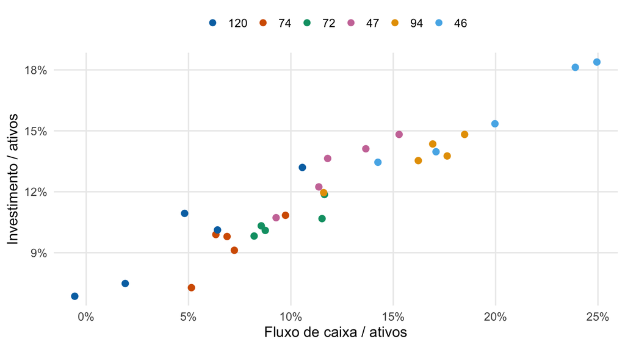

Antes de qualquer transformação, as observações contêm simultaneamente variação **entre empresas** (*between*) e variação **dentro de cada empresa ao longo do tempo** (*within*). Cada cor identifica uma das seis empresas destacadas do painel simulado.

## MQO agrupado

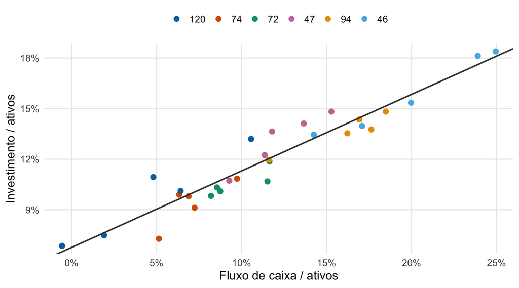

A reta de MQO agrupado mostrada é estimada com as **30 observações das seis empresas exibidas** como uma única nuvem. Ela combina variação *between* e *within*, sem eliminar a **heterogeneidade individual não observada $u_i$**.

## Médias individuais

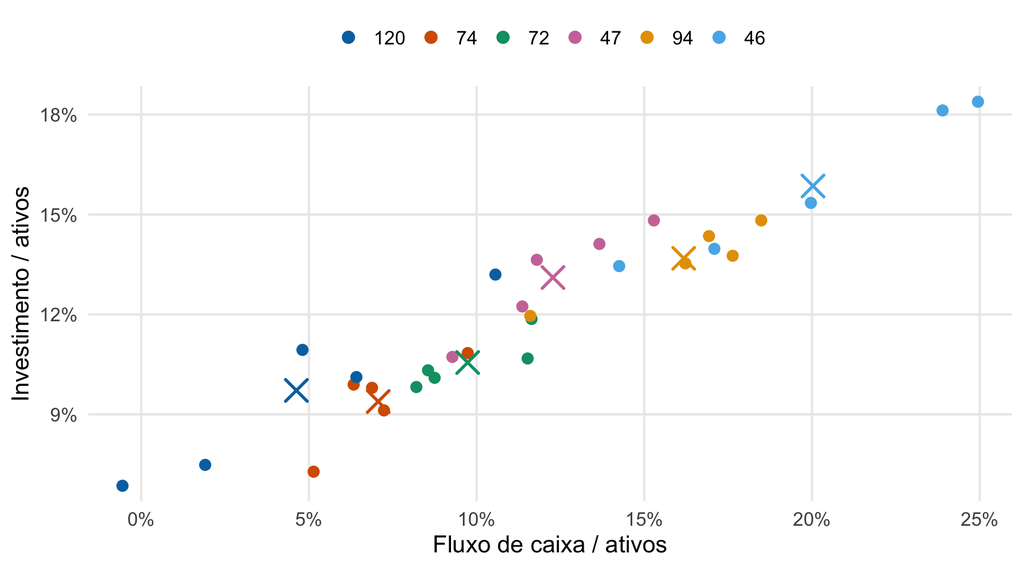

Cada X representa a média das observações de uma empresa, $(\bar x_i,\bar y_i)$, isto é, o centro de sua nuvem de pontos. As diferenças entre esses centros representam a **variação *between***.

## Variação between

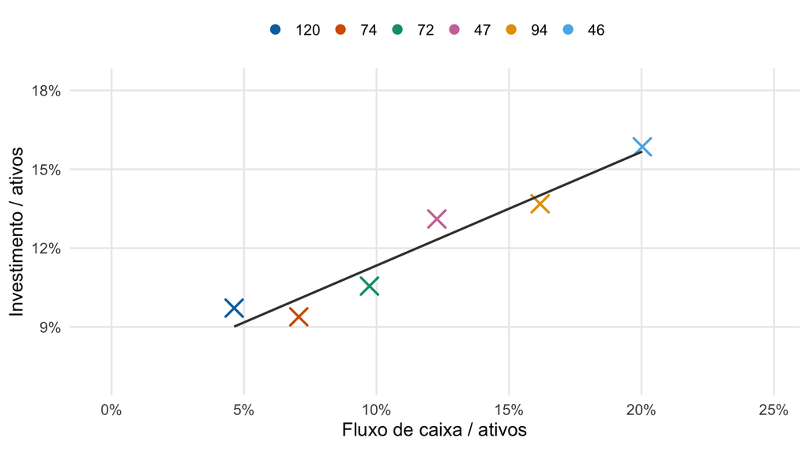

Cada ponto representa as médias de fluxo de caixa e investimento de uma empresa. A reta *between* é ajustada a essas médias e utiliza apenas a variação **entre empresas**, deixando de utilizar as oscilações dentro de cada empresa ao longo do tempo.

## Efeitos fixos: remoção completa das médias

[video not shown]

A transformação *within* elimina as diferenças entre as médias das empresas: seus centros passam a coincidir, mas a variação em torno de cada centro é preservada. Assim, elimina-se o efeito individual não observado $u_i$, e a inclinação de EF é estimada exclusivamente pela variação **dentro das empresas ao longo do tempo**.

## Efeitos fixos na escala original

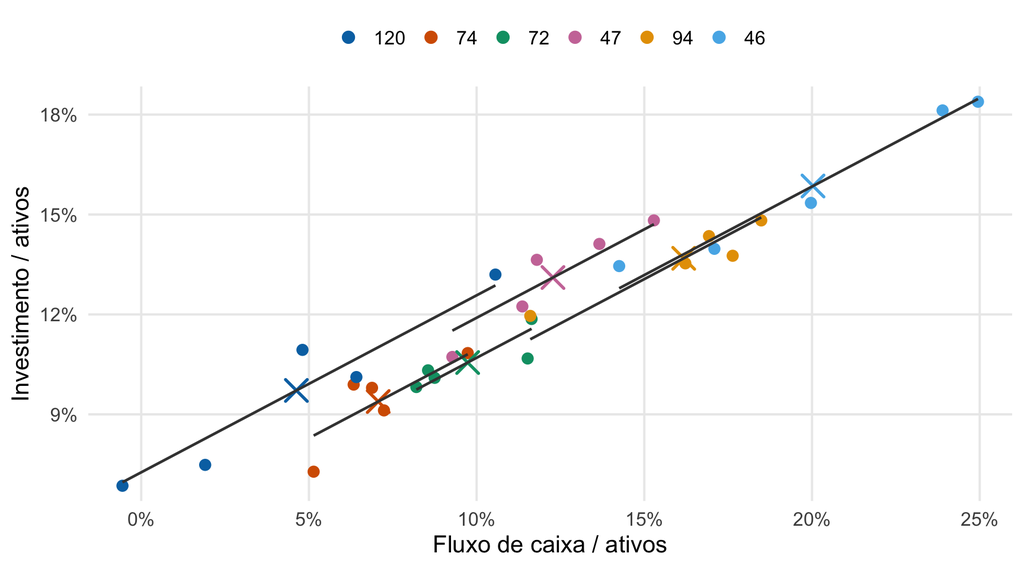

O ajuste de efeitos fixos é representado por **retas paralelas**, com uma inclinação comum estimada pela variação *within* e interceptos específicos das empresas. Cada reta passa pelo centro das observações da respectiva empresa.

## Efeitos aleatórios: remoção parcial das médias

[video not shown]

O *quasi-demeaning* subtrai apenas uma fração $\hat\alpha\approx0{,}67$ das médias individuais. Os centros das empresas se aproximam, mas não coincidem, enquanto a variação em torno de cada centro é preservada. Por isso, EA utiliza informação **within e between**. A reta final representa o ajuste de EA estimado com o painel completo.

## Efeitos fixos versus efeitos aleatórios

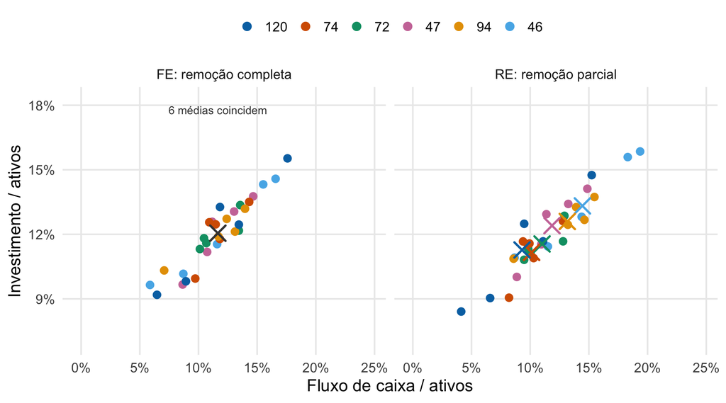

**EF elimina as diferenças entre as médias das empresas; EA apenas as reduz.** As duas transformações preservam a variação dentro de cada empresa. A diferença está na informação *between*: eliminada por EF e parcialmente preservada por EA.

## Efeitos aleatórios: lógica do estimador

O erro composto é $v_{it}=u_i+e_{it}$.

1. **Hipótese adicional:** $E(u_i\mid X_i,w_i)=0$. Somada à exogeneidade estrita de $e_{it}$, sustenta a exogeneidade do erro composto.
2. **Estrutura explorada:** se $\sigma_u^2>0$, o componente comum $u_i$ correlaciona os erros de períodos distintos da mesma unidade.
3. **Estimação:** FGLS estima essa estrutura e aplica o *quasi-demeaning*: $x_{it}^{*}=x_{it}-\hat\alpha\bar x_i$, transformando também os demais termos do modelo.

**A transformação trata a covariância dos erros; não corrige associação entre $u_i$ e as regressoras.**

## Efeitos aleatórios: propriedades e possibilidades

O *quasi-demeaning* preserva informação **within e between**.

**Sob as hipóteses convencionais do modelo**, o estimador de EA:

- é consistente para os coeficientes identificados;
- pode oferecer **maior eficiência assintótica que EF**, na estimação dos coeficientes comuns;
- permite estimar coeficientes de regressoras **invariáveis no tempo**, utilizando sua variação entre unidades.

**Essas vantagens dependem das hipóteses; preservar informação between não garante sua validade.**

## Quando considerar efeitos aleatórios?

A questão central é: **há fundamento substantivo para supor $E(u_i\mid X_i,w_i)=0$?**

- **EA é defensável** quando o desenho da pesquisa e o conhecimento do problema sustentam essa hipótese. Amostragem aleatória das unidades, por si só, não a garante.
- **EF oferece proteção contra a associação com $u_i$** quando características permanentes não observadas — como qualidade gerencial ou tecnologia — estão relacionadas às regressoras.
- **Ambos continuam exigindo exogeneidade do erro idiossincrático.** EF elimina $u_i$, mas não corrige outras fontes de endogeneidade que violem essa condição.

Estimando modelos de efeitos fixos e de efeitos aleatórios com R

## O problema econométrico

Queremos analisar como o **salário** se relaciona com características observadas das trabalhadoras, como escolaridade, experiência, tempo no emprego, localização e sindicalização.

Mas o salário também pode depender de características individuais que **não observamos**, como **habilidade** ou **perseverança**.

Representamos essas características por $u_i$:

$$\mathrm{lwage}_{it} = \beta_0 + x_{it}'\beta + w_i'\gamma + u_i + e_{it}.$$

Se $u_i$ estiver correlacionado com alguma regressora, sua omissão gera endogeneidade e pode tornar os estimadores de MQO **viesados e inconsistentes**.

**Como os dados em painel podem nos ajudar a lidar com esse problema?**

## Duas estratégias para lidar com $u_i$

### **Efeitos fixos**

A transformação *within* **elimina $u_i$** antes da estimação.

Assim, sob as demais hipóteses necessárias, EF permite estimar consistentemente os coeficientes das regressoras que variam no tempo mesmo quando $u_i$ está correlacionado com elas.

**Limitação:** os coeficientes de variáveis invariáveis no tempo não são identificados.

### **Efeitos aleatórios**

EA **não elimina completamente $u_i$** e preserva as regressoras invariáveis no tempo.

Para que o estimador seja consistente, porém, precisamos da condição adicional

$$E(u_i\mid X_i,w_i)=0.$$

No painel NLS, esse contraste será especialmente importante porque **`educ` e `black` não variam ao longo do tempo**.

## O painel NLS

Vamos trabalhar com os dados `nls_panel`, disponíveis no pacote **POE5Rdata**.

A amostra contém:

- **716 mulheres**;
- observadas em **1982, 1983, 1985, 1987 e 1988**;
- **5 observações por mulher**;
- **3.580 observações** no total.

O painel é, portanto, **balanceado**.

As mulheres da amostra estavam **empregadas** e já haviam **concluído sua escolaridade antes da primeira observação utilizada no painel**.

Por isso, `educ` permanece **invariável no tempo** para cada mulher nos cinco períodos observados.

Observar as mesmas mulheres ao longo do tempo permite separar melhor a variação **dentro de cada mulher** das diferenças **entre mulheres**.

## Variáveis do modelo

| Variável | Definição | Varia no tempo? |
| --- | --- | --- |
| `lwage` | logaritmo do salário ajustado pelo deflator do PNB | Sim |
| `educ` | anos de escolaridade concluídos | **Não** |
| `black` | = 1 se negra; 0 se branca | **Não** |
| `exper` | experiência total de trabalho | Sim |
| `tenure` | tempo no emprego atual, em anos | Sim |
| `south` | = 1 se reside no Sul | Sim |
| `union` | = 1 se é membro de sindicato | Sim |

No painel NLS, portanto:

- `exper`, `tenure`, `south` e `union` apresentam **variação dentro das mulheres ao longo do tempo**, mas não necessariamente para todas elas;
- `educ` e `black` variam **entre mulheres**, mas não ao longo do tempo para a mesma mulher.

Os termos quadráticos de `exper` e `tenure` acompanham a variação dessas regressoras.

## Estrutura do painel

No `plm`, precisamos informar quais variáveis identificam a **unidade** e o **tempo**.

```r
# Declara os índices usados pelos estimadores de dados em painel.
nls_painel <- plm::pdata.frame(nls_panel, index = c("id", "year"))

# Verifica as dimensões e o balanceamento do painel.
plm::pdim(nls_painel)
```

```
#> Balanced Panel: n = 716, T = 5, N = 3580
```

- **Índices:** `id` identifica a mulher; `year`, o ano observado.
- **Dimensões:** $N=716$ mulheres, $T=5$ observações por mulher e $NT=3.580$ observações; painel **balanceado**.

`82`, `83`, `85`, `87` e `88` correspondem aos cinco anos observados entre 1982 e 1988. **Balanceamento não exige anos consecutivos:** todas as mulheres são observadas nos mesmos cinco anos.

## Termos quadráticos na especificação

Hill, Griffiths e Lim (2018) incluem termos quadráticos para **experiência** e **tempo no emprego** na equação de salários.

Vocês devem se lembrar de que, no R, usamos `I(exper^2)` para inserir um termo quadrático.

Uma especificação como $\beta_1 \text{exper} + \beta_2 (\text{exper})^2$ permite que a relação entre a experiência e o **log do salário** apresente **curvatura**, mas o modelo com esse termo continua **linear nos parâmetros**.

**Os termos linear e quadrático devem ser interpretados conjuntamente:** o coeficiente linear, isoladamente, não descreve toda a relação com o log do salário.

## Uma referência: MQO agrupado

Como referência, começamos estimando uma única equação com todas as observações do painel.

```r
# Estima uma única equação usando todas as observações do painel.
modelo_pool <- plm::plm(
  lwage ~ educ + exper + I(exper^2) + tenure + I(tenure^2) + black + south + union,
  data = nls_painel,
  model = "pooling"
)
```

O MQO agrupado utiliza conjuntamente a variação **dentro** e **entre** as mulheres, mas **não elimina $u_i$**.

Se $u_i$ estiver correlacionado com alguma regressora, o estimador será inconsistente.

## Estimando efeitos fixos

```r
# Estima os coeficientes usando a variação dentro de cada mulher.
modelo_ef <- plm::plm(
  lwage ~ exper + I(exper^2) + tenure + I(tenure^2) + south + union,
  data = nls_painel,
  model = "within"
)
```

Com `model = "within"`, o `plm` aplica a transformação **within** e elimina a heterogeneidade individual invariável no tempo, $u_i$.

`educ` e `black` não aparecem na especificação porque também são invariáveis no tempo e seus coeficientes **não são identificados por EF**.

## Estimando efeitos aleatórios

```r
# Estima o modelo de efeitos aleatórios pelo método de Swamy–Arora.
modelo_ea <- plm::plm(
  lwage ~ educ + exper + I(exper^2) + tenure + I(tenure^2) + black + south + union,
  data = nls_painel,
  model = "random",
  random.method = "swar"
)
```

Com `model = "random"`, o `plm` utiliza a transformação de **remoção parcial das médias individuais**.

Por isso, `educ` e `black` permanecem na especificação e seus coeficientes podem ser estimados.

Mas a consistência de EA depende da condição adicional

$$E(u_i\mid X_i,w_i)=0,$$

em que, nesta aplicação, $w_i$ reúne as regressoras invariáveis no tempo: `educ` e `black`.

## Componentes de variância no modelo de EA

```r
# Mostra os componentes de variância estimados do modelo de efeitos aleatórios.
plm::ercomp(modelo_ea)
```

```
#>                   var std.dev share
#> idiosyncratic 0.03807 0.19511  0.26
#> individual    0.10827 0.32905  0.74
#> theta: 0.7437
```

No modelo de EA,

$$v_{it}=u_i+e_{it},
\qquad
\operatorname{Var}(v_{it})=\sigma_u^2+\sigma_e^2.$$

Na saída do `ercomp()`:

- `idiosyncratic`: $\hat{\sigma}_e^2=0{,}0381$, variância estimada do **erro idiossincrático**;
- `individual`: $\hat{\sigma}_u^2=0{,}1083$, variância estimada da **heterogeneidade individual não observada**;
- `std.dev`: desvios-padrão correspondentes;
- `share`: participação de cada componente na variância total do erro composto.

## Componentes de variância no modelo de EA

Para o componente individual,

$$\hat{\rho}
=
\frac{\hat{\sigma}_u^2}
{\hat{\sigma}_u^2+\hat{\sigma}_e^2}
\approx 0{,}74.$$

Assim, cerca de **74% da variância do erro composto** é atribuída à heterogeneidade individual invariável no tempo.

Sob a estrutura clássica de EA, esse valor também é a **correlação intraclasse** entre os erros compostos de duas observações da mesma mulher.

O `theta` também aparece na saída, mas tem outra função: é o parâmetro usado na **transformação de efeitos aleatórios**. Vamos interpretá-lo a seguir.

*Examinamos esses componentes aqui para compreender como o estimador de EA é construído; eles não precisam ser todos reportados rotineiramente como resultados substantivos da regressão.*

## O parâmetro da transformação de EA

No `plm`, `theta` contém a estimativa $\hat\alpha$ do parâmetro de transformação de EA, denominado $\alpha$ por Hill, Griffiths e Lim (2018).

Usando os componentes estimados para o painel NLS,

$$\hat{\alpha}
=
1-
\frac{0{,}1951}
{\sqrt{5(0{,}1083)+0{,}0381}}
\approx
0{,}7437.$$

Para uma variável $z_{it}$, aplicamos $z_{it}^{*}=z_{it}-0{,}7437\,\bar z_i$: retiramos apenas **parte da média individual**, diferentemente de EF.

**Importante:** embora $\hat{\rho}\approx0{,}74$ e $\hat{\alpha}\approx0{,}7437$ sejam numericamente próximos nesta aplicação, eles são **quantidades diferentes**: $\rho$ mede a correlação intraclasse e $\alpha$ determina a intensidade da transformação de EA.

## Comparando as estimativas

| Regressora | MQO agrupado | Efeitos fixos | Efeitos aleatórios |
| --- | --- | --- | --- |
| Educação | 0.0714 | — | 0.0733 |
| Experiência | 0.0557 | 0.0411 | 0.0436 |
| Experiência² | -0.0011 | -0.0004 | -0.0006 |
| Tempo no emprego | 0.0150 | 0.0139 | 0.0142 |
| Tempo no emprego² | -0.0005 | -0.0009 | -0.0008 |
| Negra | -0.1167 | — | -0.1167 |
| Sul | -0.1060 | -0.0163 | -0.0818 |
| Sindicato | 0.1322 | 0.0637 | 0.0802 |

Os três modelos usam as mesmas **3.580 observações**. `—` indica ausência de estimativa na especificação de efeitos fixos.

## O que a comparação mostra?

`educ` e `black` são invariáveis no tempo:

- MQO agrupado e EA estimam seus coeficientes;
- EF não consegue identificá-los.

Para as regressoras que variam no tempo, mudar a forma de tratar a heterogeneidade individual também altera as estimativas.

Por exemplo:

- `union`: **0,1322** no MQO agrupado, **0,0637** em EF e **0,0802** em EA;
- `south`: **−0,1060** no MQO agrupado, **−0,0163** em EF e **−0,0818** em EA.

Portanto, tratar, ou não, a **heterogeneidade individual não observada** pode ter consequências relevantes para os coeficientes estimados.

Mas as diferenças entre as estimativas **não determinam, por si sós, qual estimador é apropriado**.

## Por que EF e EA podem diferir?

EF elimina $u_i$ e permite que ele esteja correlacionado com as regressoras que variam no tempo.

EA utiliza também informação entre indivíduos, mas exige a condição adicional

$$E(u_i\mid X_i,w_i)=0.$$

Se essa condição for válida, juntamente com as demais hipóteses necessárias, EF e EA são consistentes para os **coeficientes comuns**, embora suas estimativas possam diferir em amostras finitas.

Se $u_i$ estiver correlacionado com uma ou mais regressoras, porém, a condição de EA falha e o estimador de efeitos aleatórios torna-se inconsistente.

**Como podemos testar se as diferenças entre as estimativas de EF e EA são compatíveis com a condição de efeitos aleatórios?**

Teste de Hausman

## Por que comparar EF e EA?

Sob as **hipóteses clássicas de efeitos aleatórios**:

- Os estimadores de EF e de EA são consistentes para os coeficientes comuns;
- O estimador de EA pode ser **assintoticamente mais eficiente** que o estimador de EF.

Mesmo nessas condições, as estimativas podem diferir devido à **variabilidade amostral**.

O teste de Hausman avalia se as **diferenças entre as estimativas de EF e EA** são compatíveis com a variabilidade amostral ou fornecem evidência de uma divergência sistemática. (Hausman, 1978)

## Hipótese do teste

A hipótese adicional de EA é $E(u_i\mid X_i,w_i)=0$: a heterogeneidade individual não observada **não está sistematicamente associada às regressoras**.

Sob as demais hipóteses necessárias, EF e EA são **consistentes para os coeficientes comuns**. O teste contrasta:

$$\begin{aligned}
H_0:&\quad \operatorname{plim}
(\hat{\boldsymbol\beta}_{EF}-\hat{\boldsymbol\beta}_{EA})=\mathbf 0,\\[8pt]
H_1:&\quad \operatorname{plim}
(\hat{\boldsymbol\beta}_{EF}-\hat{\boldsymbol\beta}_{EA})\neq\mathbf 0.
\end{aligned}$$

**Leitura de $H_0$:** as diferenças entre os estimadores desaparecem em grandes amostras; as estimativas **não precisam ser iguais na amostra observada**.

## Estatística de Hausman

Considere as diferenças entre os coeficientes comuns: $\widehat{\boldsymbol\Delta}=\hat{\boldsymbol\beta}_{EF}-\hat{\boldsymbol\beta}_{EA}$. Como em um **teste t**, precisamos avaliar seu tamanho em relação à variabilidade amostral.

**Por que subtrair as matrizes?** EF e EA são estimados com os mesmos dados e são correlacionados. Sob $H_0$ e as condições de eficiência de EA, uma identidade para essa covariância permite estimar:

$$\widehat{\operatorname{Var}}(\widehat{\boldsymbol\Delta})
=\widehat V_{EF}-\widehat V_{EA}.$$

A **estatística de Hausman** avalia o afastamento conjunto de zero, considerando as variâncias e covariâncias das diferenças:

$$H=\widehat{\boldsymbol\Delta}'
(\widehat V_{EF}-\widehat V_{EA})^{-1}
\widehat{\boldsymbol\Delta}.$$

Sob $H_0$ e as hipóteses do teste convencional, $H\overset{a}{\sim}\chi_q^2$, com $q$ **coeficientes comuns comparados**. (Hansen, 2022; Hill, Griffiths e Lim, 2018)

## Coeficientes comparáveis

O teste de Hausman compara apenas os **coeficientes estimados tanto por EF quanto por EA**.

No painel NLS, são **seis coeficientes comuns**:

- `exper` e `I(exper^2)`: experiência e seu termo quadrático;
- `tenure` e `I(tenure^2)`: tempo no emprego e seu termo quadrático;
- `south`: residência no Sul;
- `union`: participação sindical.

As regressoras `educ` e `black` são **invariáveis no tempo** e seus coeficientes não são identificados por EF. Portanto, **não entram no teste**.

Consequentemente, o teste **não avalia diretamente a consistência das estimativas de EA para essas duas variáveis**.

## Quando o valor-p do Hausman é confiável?

O valor-p convencional depende das **hipóteses que justificam a estatística e sua distribuição de referência**.

O modelo de EA admite **correlação entre os erros compostos** $v_{it}=u_i+e_{it}$ de períodos distintos, provocada pelo componente comum $u_i$.

Sob as hipóteses convencionais, os componentes são homocedásticos e os erros idiossincráticos $e_{it}$ **não apresentam correlação serial**.

Portanto, o teste utiliza uma **estrutura específica de covariância** do erro composto, que sustenta a eficiência de EA sob $H_0$; não admite formas arbitrárias de heterocedasticidade ou dependência temporal. (Hansen, 2022; Hill, Griffiths e Lim, 2018)

## Quando o valor-p do Hausman é confiável?

Se a estrutura de covariância convencional for inadequada, EA pode deixar de ser eficiente, **mesmo que EF e EA continuem consistentes**.

Nesse caso, $\widehat V_{EF}-\widehat V_{EA}$ pode não estimar corretamente a covariância das diferenças, e a **referência qui-quadrado pode ser inválida**.

**Não basta substituir as matrizes convencionais por matrizes robustas a agrupamentos:** a identidade que justifica a subtração deixa de valer em geral. É necessário um procedimento de teste adequado à estrutura dos erros. (Hansen, 2022; Hill, Griffiths e Lim, 2018)

**Na aplicação a seguir**, o valor-p será interpretado sob as hipóteses do **teste convencional**, cuja execução não verifica essas hipóteses.

## Hausman no NLS

Aplicamos o **teste convencional de Hausman** aos modelos de EF e EA estimados anteriormente.

```r
# Compara os seis coeficientes comuns aos modelos de EF e EA.
teste_hausman <- plm::phtest(modelo_ef, modelo_ea)

# Exibe a estatística, os graus de liberdade e o valor-p.
teste_hausman
```

```
#>
#>  Hausman Test
#>
#> data:  lwage ~ exper + I(exper^2) + tenure + I(tenure^2) + south + union
#> chisq = 20.725, df = 6, p-value = 0.002055
#> alternative hypothesis: one model is inconsistent
```

**Resultado do teste:**

$$H = 20{,}725,\qquad q = 6,\qquad p = 0{,}002055.$$

Como $p<0{,}05$, **rejeitamos $H_0$ ao nível de 5%**.

**Mantidas a consistência de EF e as demais hipóteses do teste**, há evidência contra a consistência de EA para pelo menos um dos coeficientes comuns.

## Como interpretar a rejeição?

Uma explicação econômica para o resultado no NLS é a violação da **hipótese adicional de exogeneidade de EA**:

$$E(u_i\mid X_i,w_i)=0.$$

Se $u_i$ estiver sistematicamente associado às regressoras, **EA pode ser inconsistente**, enquanto EF permanece consistente **sob suas próprias hipóteses**.

**No modelo salarial:** habilidade, motivação ou perseverança não observadas podem estar associadas à experiência, ao tempo no emprego ou à participação sindical.

Essa é uma **explicação plausível**, não uma causa identificada pelo teste. (Hansen, 2022; Hill, Griffiths e Lim, 2018)

## Como interpretar a rejeição?

A interpretação depende de **quais hipóteses permanecem válidas**:

| Situação | Consequência |
| --- | --- |
| EF consistente e teste corretamente construído | A rejeição fornece evidência contra a especificação de EA, nos coeficientes comparados. |
| Falha a exogeneidade de $e_{it}$ | EF também pode ser inconsistente e deixa de fornecer a referência necessária para essa interpretação. |
| Covariância convencional inadequada | O valor-p pode ser inválido, mesmo que EF e EA continuem consistentes. |

**Hausman não identifica a causa da divergência nem quais regressoras são endógenas; também não valida a consistência de EF.** (Hansen, 2022; Hill, Griffiths e Lim, 2018)

## Por que não escolher EF ou EA apenas pelo teste de Hausman?

A regra automática

$$\text{rejeita }H_0\;\longrightarrow\;\text{EF}
\qquad
\text{não rejeita }H_0\;\longrightarrow\;\text{EA}$$

define um **estimador de pré-teste**: o resultado do teste determina qual estimador será utilizado.

**O problema é a dependência entre seleção e estimação.** A decisão usa as próprias estimativas que serão reportadas: o resultado do teste é aleatório e correlacionado com os estimadores. Essa seleção pode introduzir **viés no estimador de pré-teste**. (Hansen, 2022)

Hausman deve atuar como **teste de especificação**, complementando uma decisão fundamentada nas hipóteses e no problema empírico. (Hansen, 2022)

## Como utilizar o teste de Hausman na prática?

**1. Antes:** avalie a exogeneidade de $e_{it}$ e de $u_i$, a especificação e a adequação do teste à estrutura dos erros. Considere os objetivos da pesquisa, inclusive a identificação de efeitos de variáveis invariáveis no tempo.

**2. Ao apresentar:** informe os modelos, os coeficientes comparados, a versão do teste, a estatística, os graus de liberdade, o valor-p e as hipóteses que sustentam sua interpretação.

**3. Ao interpretar:**

- **Rejeição:** questiona EA sob as condições mantidas; não identifica a causa nem valida EF.
- **Não rejeição:** não comprova a consistência de EA.

**Executar não é verificar hipóteses:** no NLS, `plm::phtest()` não avalia a presença de heterocedasticidade ou correlação serial de $e_{it}$. (Hansen, 2022; Hill, Griffiths e Lim, 2018)

Atividade 2

## Atividade Prática 2 (AP2)

**Objetivo:** utilizar os dados NLS para comparar os estimadores de **MQO agrupado**, **efeitos fixos (EF)** e **efeitos aleatórios (EA)** e interpretar criticamente o **teste de Hausman**.

**Tempo previsto:** 1 hora, no máximo.

**Orientações**

- Utilize o arquivo `02-atividade.qmd`, ele contém o códito para carregar os pacotes e os dados.
- Complete as células de código R (*chunks*) e apresente respostas **claras e objetivas**.
- Consulte os slides. O objetivo é **compreender os estimadores e suas hipóteses**, não memorizar comandos.
- Substitua `SEU NOME` no campo `author` do YAML e gere o **HTML** com os códigos, resultados e interpretações.

## Referências

BALTAGI, B. H. **[Econometric Analysis of Panel Data](https://doi.org/10.1007/978-3-030-53953-5)**. 6. ed. Cham: Springer, 2021.

___. [Teaching Panel Data Econometrics](https://doi.org/10.1007/978-3-031-97942-2_5). *Em*: HILLEBRAND, E.; GRIFFITHS, W. (Eds.). **Teaching Econometrics: A Tribute to R. Carter Hill**. Advanced Studies em Theoretical e Applied Econometrics. Cham: Springer, 2026. v. 56p. 91–102.

CROISSANT, Y.; MILLO, G. **[Panel Data Econometrics with R](https://doi.org/10.1002/9781119504641)**. [s.l.] John Wiley & Sons, 2018.

HANSEN, B. E. **Econometrics**. Princeton, NJ: Princeton University Press, 2022.

HAUSMAN, J. A. [Specification Tests in Econometrics](https://doi.org/10.2307/1913827). **Econometrica**, v. 46, n. 6, p. 1251–1271, 1978.

HILL, R. C.; GRIFFITHS, W. E.; LIM, G. C. **Principles of Econometrics**. 5. ed. Hoboken, NJ: John Wiley & Sons, 2018.

WOOLDRIDGE, J. M. **Econometric Analysis of Cross Section and Panel Data**. 2. ed. Cambridge, MA: The MIT Press, 2010.

___. **Introductory Econometrics: A Modern Approach**. 8. ed. [s.l.] Cengage Learning, 2025.